# Analyzing mass spectrometry data with limpa

Mengbo Li and Gordon K. Smyth

First version 30 December 2024, Last revised 20 February 2026

#### Abstract

Mass spectrometry is a powerful tool in biomedical research. Technology advances have enabled high-throughput proteomics profiling of biological samples with the increasingly deeper coverage of the proteome, but missing values are still ubiquitous in MS-based proteomics data. Single-cell MS-based proteomics has also started to become available, with increased frequency of missing values. The limpa package implements a pipeline for quantification and differential expression analysis of mass-spectrometry (MS) proteomics data, incorporating probabilistic recovery of information from missing values. The package accepts precursor-level data, usually including missing values, and produces complete protein quantifications without the need for imputation. More generally, the package can accept intensity data at any feature level (fragments, precursor ions, peptides, PTMs) and can quantify abundance at any higher or equal level (PTMs, peptides, proteins). A key feature is the ability to quantify an expression value for every protein and every sample, regardless of the number of quantified precursors for each protein or the number of missing values at the precursor level. Another key feature is the ability to propagate quantification uncertainty through to the differential expression analysis, using variance modeling and precision weights, increasing statistical power while avoiding false discoveries. Each protein quantification is associated with a standard error, allowing limpa to appropriately downweight less reliable quantifications. limpa produces a linear model object suitable for downstream analysis with the limma package, allowing complex experimental designs and other downstream tasks such as the gene ontology or pathway analysis. The package name (“limpa”) is an acronym for “Linear Models for Proteomics Data”. This vignette was made with limpa version 1.3.7 and limma version 3.67.0.

# Background

limpa assumes that label-free proteomics profiling has been performed on a series of biological samples, and that precursor ion intensities have been obtained for each sample (Luo et al 2023). limpa reads the precursor intensity data from popular software tools such as DIA-NN (Demichev et al 2020), Spectronaut (https://staging.biognosys.com), FragPipe (Yu et al 2023), or MaxQuant (Tyanova et al 2016). In each case, the precursor quantifications are read into a wide-format (precursor by sample) matrix of log-intensities. The only other information required to start a limpa analysis is a vector specifying the protein or protein-group membership of each precursor.

Precursor intensities typically include missing values for some samples, which cause considerable problems for downstream analyses. The missing values can’t just be ignored, because they occur more often at low intensities, and missing value imputation also introduces biases and problems. limpa uses statistical models developed by Li & Smyth (2023) to evaluate how much information can be recovered from the missing values, quantifying the overall missing value “mechanism” into a detection probability curve (DPC). limpa uses the DPC, together with a Bayesian model, to summarize the precursor quantifications into protein-level quantifications and to undertake limma-based differential expression analyses (Ritchie et al 2015, Li 2024, Li et al 2025).

limpa has chosen to focus on precursor ions (aka peptide ions), because they are the basic quantification unit for both DDA and DIA proteomics. More generally, however, the package can accept intensity data at any feature level (fragments, precursor ions, peptides, proteins, PTMs) and can quantify abundance at any equal or higher level (PTMs, peptides, proteins). All that is required is a matrix of log-intensities and an annotation vector identifying the higher level annotation group associated with each feature. limpa can therefore quantify proteins from fragment or precursor or peptide intensities, or can even work directly on a matrix of protein-level values, such as from maxLFQ, although lower level input data is recommended if available. limpa can also quantify expression at the peptide level, starting from fragments or precursors, and can conduct differential isoform usage analyses based on the resulting peptide quantifications.

# How to get help

Any questions about limpa can be sent to the [Bioconductor support forum](https://support.bioconductor.org).

Installation instructions, code browsing and other information is available from the [Bioconductor home page for limpa](https://doi.org/doi:10.18129/B9.bioc.limpa).

This documentation can be accessed from https://smythlab.github.io/limpa/.

# How to cite

Li M, Cobbold SA, Smyth GK (2025). Quantification and differential analysis of mass spectrometry proteomics data with probabilistic recovery of information from missing values. *bioRxiv* 2025/651125. [doi:10.1101/2025.04.28.651125](https://doi.org/10.1101/2025.04.28.651125)

# Quick start

If `y.prec` is a matrix of precursor-level log2-intensities (including NAs), `protein.id` is a vector of protein IDs, and `design` is a design matrix, then the following code will quantify complete log2-expression for the proteins without missing values and will conduct a differential expression analysis defined by the design matrix.

```
library(limpa)
dpcest <- dpc(y.prec)
y.protein <- dpcQuant(y.prec, protein.id, dpc=dpcest)
fit <- dpcDE(y.protein, design)
fit <- eBayes(fit)
topTable(fit)
```

# Example analysis

Real proteomics datasets are too large to analyze in this vignette (see https://github.com/smythlab/limpa/ for case studies with real data), but we can demonstrate a complete reproducible analysis using a small simulated data. First, generate the dataset:

```r
> library(limpa)
> set.seed(20241230)
> y.prec <- simProteinDataSet()
```

The dataset is stored as a limma EList object, with components `E` (log2-intensities), `genes` (feature annotation) and `targets` (sample annotation). The simulation function can generate any number of precursors or proteins but, by default, the dataset has 100 precursors belonging to 25 proteins and the samples are in two groups with $n=5$ replicates in each group. About 40% of the expression values are missing.

```r
> dim(y.prec)
```

```
[1] 100  10
```

```r
> head(y.prec$genes)
```

```
             Protein DEStatus
Peptide001 Protein01    NotDE
Peptide002 Protein01    NotDE
Peptide003 Protein01    NotDE
Peptide004 Protein01    NotDE
Peptide005 Protein02    NotDE
Peptide006 Protein02    NotDE
```

```r
> table(y.prec$targets$Group)
```

```
1 2
5 5
```

```r
> mean(is.na(y.prec$E))
```

```
[1] 0.389
```

Next we estimate the intercept and slope of the detection probability curve, which relates the probability of detection to the underlying precursor log-intensity level on the logit scale.

```r
> dpcest <- dpc(y.prec)
```

```
1 peptides are completely missing in all samples.
```

```r
> dpcest$dpc
```

```
  beta0   beta1
-3.8185  0.7455
```

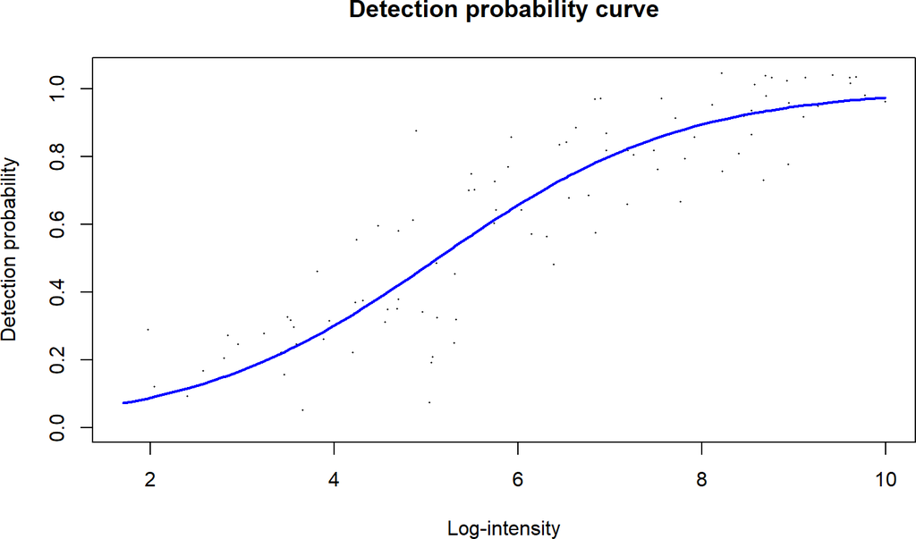

```r
> plotDPC(dpcest)
```

Then we use the DPC to quantify the protein log2-expression values, using the DPC to represent the missing values.

```r
> y.protein <- dpcQuant(y.prec, "Protein", dpc=dpcest)
```

```
Estimating hyperparameters ...
```

```
Quantifying proteins ...
```

```
Proteins: 25  Precursors: 100 (100%)
```

There are no longer any missing values, and the samples now cluster into groups. The `plotMDSUsingSEs()` function is similar to `plotMDS()` in the limma package, but takes account of the standard errors generated by `dpcQuant()`.

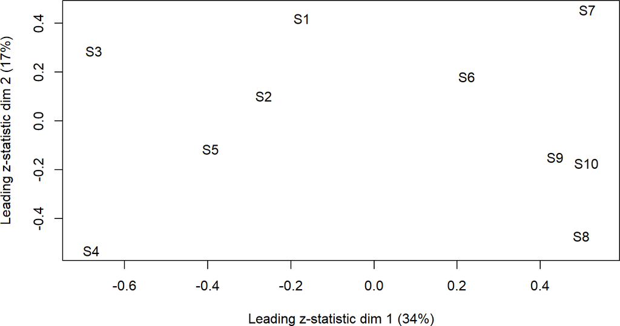

```r
> plotMDSUsingSEs(y.protein)
```

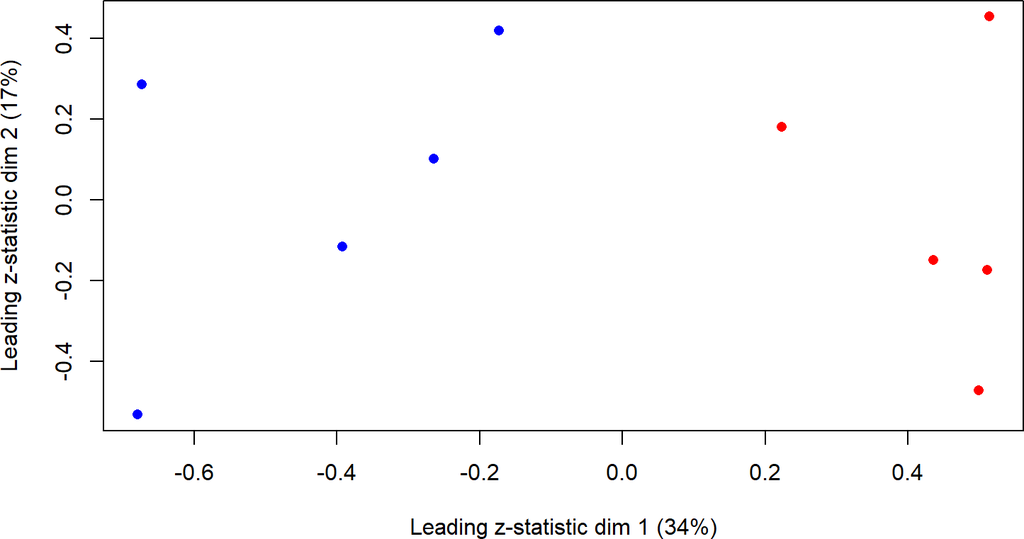

```r
> Group <- factor(y.prec$targets$Group)
> Group.color <- Group
> levels(Group.color) <- c("blue","red")
> plotMDSUsingSEs(y.protein, pch=16, col=as.character(Group.color))
```

Finally, we conduct a differential expression analysis using `dpcDE()`. The `dpcDE` function calls limpa’s `voomaLmFitWithImpution` function, which is an extension of limma’s `vooma()` approach. `voomaLmFitWithImputation` computes precision weights, in an analogous way to `voom` for RNA-seq, but instead of using count sizes to predict the variances it uses the quantification precisions from `dpcQuant`. The plot shows how `dpcDE` predicts the protein-wise variances from the quantification uncertainties and from the averge log-intensity levels.

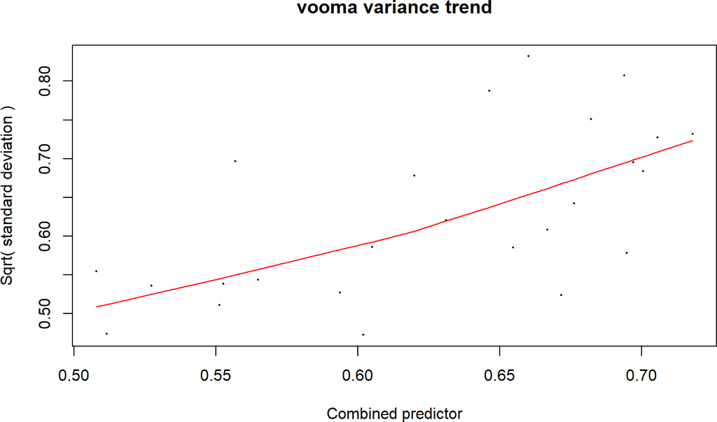

```r
> design <- model.matrix(~Group)
> fit <- dpcDE(y.protein, design, plot=TRUE)
```

`dpcDE` is analogous to the `lmFit` function in limma, and output from `dpcDE` enters into downstream limma analyses in the same way that output from `lmFit` would. To get a table of DE proteins we proceed

```r
> fit <- eBayes(fit)
> topTable(fit, coef=2)
```

```
          DEStatus NPrec PropObs   logFC AveExpr      t   P.Value adj.P.Val
Protein23       Up     4   0.950  0.9791   9.243  4.696 3.037e-05 0.0007592
Protein22       Up     4   1.000  0.7335   8.912  4.062 2.173e-04 0.0025529
Protein24     Down     4   0.975 -0.8420   9.329 -3.948 3.063e-04 0.0025529
Protein08       Up     4   0.450  0.6917   4.720  2.258 2.943e-02 0.1471725
Protein13    NotDE     4   0.650 -0.6116   5.960 -2.349 2.378e-02 0.1471725
Protein07    NotDE     4   0.425  0.6814   4.266  2.150 3.757e-02 0.1565210
Protein11    NotDE     4   0.650  0.5462   5.157  1.825 7.541e-02 0.2693390
Protein10    NotDE     4   0.375  0.4912   4.801  1.534 1.328e-01 0.4148864
Protein09    NotDE     4   0.275  0.3823   4.653  1.189 2.413e-01 0.6032065
Protein21    NotDE     4   0.850  0.3261   8.483  1.384 1.741e-01 0.4835411
                 B
Protein23  2.25712
Protein22  0.31342
Protein24  0.08621
Protein08 -3.76750
Protein13 -3.77157
Protein07 -3.99409
Protein11 -4.61641
Protein10 -5.11761
Protein09 -5.54192
Protein21 -5.58621
```

To view the log-expression values for the top DE protein, together with standard errors:

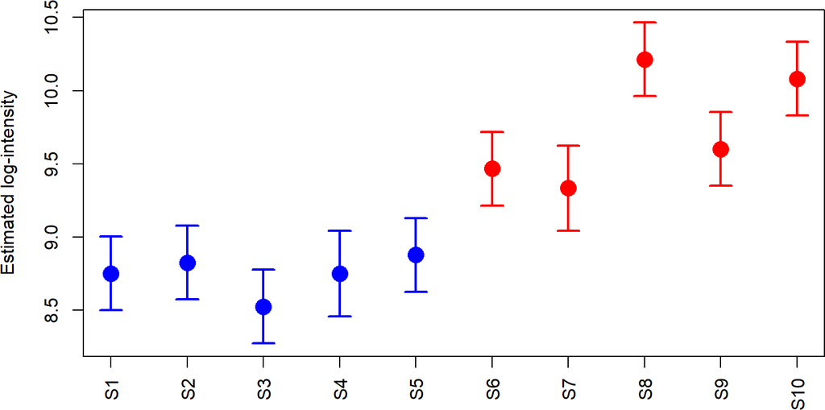

```r
> plotProtein(y.protein, "Protein23", col=as.character(Group.color))
```

# Quantification without protein summaries

For some proteomics applications, such as PTM or isoform analyses, it is desirable to undertake quantification and differential expression analysis for every row of data instead of summarizing multiple rows into proteins. To impute and quantify on a row-wise base, use the `dpcQuantByRow` function instead of `dpcQuant`, for example

```
y.prec.complete <- dpcQuantByRow(y.prec, dpc=dpcest)
```

The input is similar as for `dpcQuant` except there is no need to specify protein IDs, and the downstream DE analysis is the same.

# Data input

The limpa pipeline starts with a matrix of precursor intensities (rows for precursors and columns for samples) and a character vector of protein IDs. (The introduction here will focus on the protein-level differential expression based on precursor level input intensities, although other input and quantification levels are possible, briefly discussed below.) The input data can be conveniently supplied as a limma EList object, but a plain numeric matrix containing the log-intensities is also acceptable. Non-detected precursors should be entered as `NA`.

limpa includes the functions `readDIANN()`, `readSpectronaut()`, `readFragPipe()` and `readMaxQuant()`, which read precursor level data output by the popular mass spectrometry quantification tools DIA-NN, Spectronaut, FragPipe, and MaxQuant respectively. In each case, limpa directly reads standard format files output by those tools without any need for prior processing by the analyst.

The `readDIANN()` function reads the main DIA-NN “Report” file, and it supports either the tab-delimited text format written by DIA-NN version 1 or the Apache Parquet format used by DIA-NN version 2. For example,

```r
> y.prec <- readDIANN("Report.tsv")
```

will read a `Report.tsv` file written by DIA-NN v1 from the current working directory, and

```r
> y.prec <- readDIANN("Report.parquet")
```

will read a `Report.parquet` file written by DIA-NN v2. The format can be specified explicity but, by default, is detected automatically from the Report file name.

The `readDIANN()` function also includes the option to filter peptide-precursors based on Q-values. While limpa is robust to different filtering choices, we recommend the following settings for data searched with match-between-run (MBR):

```r
> y.prec <- readDIANN("Report.tsv",
+              q.columns = c("Q.Value","Lib.Q.Value","Lib.PG.Q.Value"),
+              q.cutoffs = 0.01)
```

and the following settings if searched without MBR:

```r
> y.prec <- readDIANN("Report.tsv",
+              q.columns = c("Q.Value","Global.Q.Value","Global.PG.Q.Value"),
+              q.cutoffs = 0.01)
```

These settings follow suggestions from Thierry Nordmann (Max Planck Institute of Biochemistry).

After reading in the data, it is common to filter out non-proteotypic peptides by

```r
> y.prec <- filterNonProteotypicPeptides(y.prec)
```

and to filter out compound protein groups (protein groups mapped to two or more protein IDs) by

```r
> y.prec <- filterCompoundProteins(y.prec)
```

These filtering steps are not required by limpa but help with downstream interpretation of the results.

Protein groups can also be filtered by number of peptides, typically to remove proteins with only one detected precursor:

```r
> y.prec <- filterSingletonPeptides(y.prec, min.n.peptides = 2)
```

This step is entirely optional. We generally recommend that users keep all proteins in order to retain maximum information. The `dpcQuant()` function will still quantify complete data even for proteins with just one peptide.

Note that peptides do not need to be filtered based on the proportion of detected or missing values. limpa can process peptides correctly even if the number of detections is small.

# The detection probability curve

Missing values for some peptides in some samples has complicated the analysis of MS proteomics data. Peptides with very low expression values are frequently not detected, but peptides at high expression levels may also be undetected for a variety of reasons that are not completely understood or easily predictable, for example ambiguity of their elution profile with that of other peptides. If `y` is the true expression level of a particular peptide in a particular sample (on the log2 scale), then limpa assumes that the probability of detection is given by
$$P(D | y) = F(\beta_0 + \beta_1 y)$$
where $D$ indicates detection, $\beta_0$ and $\beta_1$ are the intercept and slope of the DPC and $F$ is the logistic function, given by `plogis` in R. This probability relationship is called the detection probability curve (DPC) in limpa. The slope $\beta_1$ measures how dependent the missing value process is on the underlying expression level. A slope of zero would means completely random missing values, while very large slopes correspond to left censoring. The DPC allows limpa to recover information in a probabilistic manner from the missing values. The larger the slope, the more information there is to recover. We typically find $\beta_1$ values between about 0.7 and 1 to be representative of real MS data.

The DPC is difficult to estimate because `y` is only observed for detected peptides, and the detected values are a biased representation of the complete values that in principle might have been observed had the missing value mechanism not operated. limpa uses a mathematical exponential tilting argument to represent the DPC in terms of observed values only, which provides a means to estimate the DPC from real data. The DPC slope $\beta_1$ is nevertheless often under-estimated if the variability of each peptide is large.

# Quantification

limpa uses the DPC, together with a Bayesian model, to estimate the expression level of each protein in each sample. It fits an additive model
$$\mu_{ij} = \gamma_i + \delta_j$$
to the peptide log-intensities for each protein, where $\mu_{ij}$ is the expected log-expression of peptide $j$ in sample $i$, $\gamma_i$ is the log-expression level of the protein in sample $i$ and $\delta_j$ is the baseline effect for peptide $j$. A sum-to-zero constraint is applied to the peptide effects $\delta_j$ so that the protein expression $\gamma_i$ represents the average log-expression of the peptides in sample $i$. The log-likelihood consists of squared residuals for each observed peptide value and the log probability of being missing for each non-detected peptide value. A multivariate normal prior is also applied to the protein log-expression values, where the prior is estimated from the global data for all proteins. DPC-Quant maximizes the log-posterior with respect to the $\gamma_i$s and $\delta_j$s, and the final $\gamma_i$s become the protein quantifications. DPC-Quant also returns the posterior standard error with which each log-expression value is estimated.

# Differential expression

Finally, the protein log2-expression values and associated uncertainties are passed to the `voomaLmFitWithImputation` function, which computes precision weights for each observation and fits protein-wise linear models. `voomaLmFitWithImputation` combines features from the `voomaLmFit` and `voomLmFit` functions in the limma and edgeR packages, with some extensions specific to proteomics data with missing values. It uses both protein expression and the quantification standard errors to predict the protein-wise variances and, hence, to construct precision weights for downstream linear modelling. This allows the uncertainty associated with missing values imputation to be propagated through to the differential expression analysis. `voomaLmFitWithImputation` also gives special consideration to instances where all the expression values for a particular protein are imputed for one or more treatment conditions, ensuring robust differential expression analyses even for proteins with only a small proportion of detected peptides.

limpa’s `dpcDE` function is a wrapper function, passing the appropriate standard errors from `dpcQuant` to `voomaLmFitWithImputation`. The limpa package has the full generality of limma analysis pipelines, allowing any complex experimental design and other downstream tasks such as the gene ontology or pathway analysis. limpa works with any design matrix, with any combination of explanatory factors and covariates. The `dpcDE()` function accepts any argument that `voomaLmFitWithImputation` or `voomaLmFit` do. For example, `dpcDE(y.protein, design, sample.weights=TRUE)` can be used to downweight outlier samples. Or `dpc(y.protein, design, block=subject)` could be used to model the correlation between repeated observations on the same subject.

Note that limpa differential expression analyses must be done using `dpcDE` rather than using regular limma functions such as `lmFit` or `arrayWeights`. Only `dpcDE` is able to make full use of the standard errors and observation counts computed by `dpcQuant()`. Once `dpcDE` has been run, however, one returns to standard limma pipelines.

# Working with data already summarized at the protein-level

We recommend inputing precursor-level data to limpa, but limpa can also operate on intensities, such as MaxLFQ, that have already been summarized at the protein level, by using `dpcQuantByRow` function instead of `dpcQuant`.

# Post-translational modifications (PTMs) or immunoprecipitation mass spectrometry (IP-MS)

To analyse PTMs, one would work with a tool such as Spectronaut to obtain intensities for each distinct modification. limpa can accept a matrix of PTM-level intensities, and can undertake differential abundance analyses of the PTMs. Again, one would use `dpcQuantByRow` in this case instead of `dpcQuant`. The same approach can be used for IP-MS (Corso et al 2026).

# Differential peptide usage

limpa can also detect proteins showing differential isoform usage between conditions. To detect differential peptide usage for each protein between experimental conditions, first use `dpcQuant` to quantify expression at the peptide level, then use `dpcDE` to fit peptide-level linear models, after which `limma`’s `diffSplice` function tests for differential usage. The full pipeline is shown in a case study (see link below).

# Very large datasets

limpa has modest memory requirements and can be run on laptop, even with 100s or 1000s of samples. The most time-consuming step is `dpcQuant()`, which is fast for small to moderate datasets, but can be relatively slow, taking several hours, for very large datasets with thousands of samples. A dataset with 200 samples takes about 30 minutes to analyze on a MacBook Pro laptop, even if all proteins and precursors are retained in the analysis. For very large datasets with 1000s of samples, we suggest an alternative pipeline using `imputeByExpTilt()`.

# Further documentation

- **[Case studies with real data](https://github.com/smythlab/limpa/)**
- **[Frequently asked questions](https://smythlab.github.io/limpa/FAQ.html)**
- **[Reference Manual (pdf)](https://bioconductor.org/packages/release/bioc/manuals/limpa/man/limpa.pdf)**

# Acknowledgements

The authors are grateful for comments and suggestions from many individuals including Jumana Yousef, Jonathan Algoo, Samuel Granjeaud and Julia Marchingo.

# Funding

The limpa project was supported by Chan Zuckerberg Initiative EOSS grant 2021-237445, by Melbourne Research and CSL Translational Data Science Scholarships to ML, and by NHMRC Investigator Grant 2025645 to GS.

# Cited references

Corso LD, River ISa, Al Halawani A, Gerak CAN, Gannon D, Ozaydin O, Li M, Thyagarajan K, Niezabitowski L, Chua NK, Tan W, Wudy SI, McLysaght A, Smyth GK, Shakeel S, Feltham R, Vervoort SJ (2026). INTS12 bridges Integrator and NELF to prevent the release of non-processive RNA polymerase II complexes. *bioRxiv* [doi:10.64898/2026.01.16.699819](https://doi.org/10.64898/2026.01.16.699819).

Demichev V, Messner CB, Vernardis SI, Lilley KS, Ralser M (2020). DIA-NN: neural networks and interference correction enable deep proteome coverage in high throughput. *Nature Methods* 17(1), 41-44.

Li M, Smyth GK (2023). Neither random nor censored: estimating intensity-dependent probabilities for missing values in label-free proteomics. *Bioinformatics* 39(5), btad200. [doi:10.1093/bioinformatics/btad200](https://doi.org/10.1093/bioinformatics/btad200)

Li M, Cobbold SA, Smyth GK (2025). Quantification and differential analysis of mass spectrometry proteomics data with probabilistic recovery of information from missing values. *bioRxiv* 2025/651125. [doi:10.1101/2025.04.28.651125](https://doi.org/10.1101/2025.04.28.651125)

Li M (2024). *Linear Models and Empirical Bayes Methods for Mass Spectrometry-based Proteomics Data*. PhD Thesis, University of Melbourne. http://hdl.handle.net/11343/351600

Ritchie ME, Phipson B, Wu D, Hu Y, Law CW, Shi W, Smyth GK (2015). limma powers differential expression analyses for RNA-sequencing and microarray studies. *Nucleic Acids Research* 43, e47. doi:10.1093/nar/gkv007

Tyanova S, Temu T, Cox J (2016). The MaxQuant computational platform for mass spectrometry-based shotgun proteomics. *Nature Protocols* 11, 2301-2319.

Yu F, Teo GC, Kong AT, Fröhlich K, Li GX, Demichev V, Nesvizhskii AI (2023) Analysis of DIA proteomics data using MSFragger-DIA and FragPipe computational platform. *Nature communications*, 14(1), 4154.